# Kaggle_Top100

```python
from IPython.display import HTML

HTML('''<script>
code_show=true;
function code_toggle() {
 if (code_show){
 $('div.input').hide();
 } else {
 $('div.input').show();
 }
 code_show = !code_show
}
$( document ).ready(code_toggle);
</script>
 <a href="javascript:code_toggle()"></a>.''')
```

.

**Name** - Vivek Chatterjee

**Date** - 22-05-2018

This is an assignment I am doing using a dataset from Kaggle.

**Objective** - To Provide In-Depth Analysis using interactive visualizations.

**Dataset** - https://www.kaggle.com/idanerez/top-100-cryptos-updates-every-15-min

**Other Information** -

*Context*

The past two months were crazy in the crypto market. The goal is to allow analyze correlations between Bitcoin and other Crypto Currencies in order to do smarter day-trading.

*Content*

This data set was updated every 15 min using Coin Market Cap API and includes the top 100 coins market cap, price in USD and price in BTC. Every row has its update time in EST Time zone

### Import the necessary libraries

```python
import pandas as pd
import numpy as np
import matplotlib.pyplot as plt
import seaborn as sns
%matplotlib inline

from scipy.stats import norm

import plotly.offline as py
import plotly.plotly as pyp
from plotly.offline import download_plotlyjs, init_notebook_mode, plot, iplot
import plotly.graph_objs as go
import plotly.figure_factory as ff
py.init_notebook_mode(connected=True)

import cufflinks as cf
init_notebook_mode(connected=True)
cf.go_offline()
```

[output not shown]

```python
data = pd.read_csv('top100cryptos_15min.csv')
```

```python
data.head(10)
```

|  | symbol | rank | price_usd | price_btc | market_cap_usd | date | time |
| --- | --- | --- | --- | --- | --- | --- | --- |
| 0 | BTC | 1 | 11598.100000 | 1.000000 | 1.960334e+11 | 2018-03-05 | 18:39:25 |
| 1 | ETH | 2 | 854.503000 | 0.073891 | 8.374739e+10 | 2018-03-05 | 18:39:11 |
| 2 | XRP | 3 | 0.961074 | 0.000083 | 3.757026e+10 | 2018-03-05 | 18:39:01 |
| 3 | BCH | 4 | 1272.540000 | 0.110040 | 2.163538e+10 | 2018-03-05 | 18:39:12 |
| 4 | LTC | 5 | 211.759000 | 0.018311 | 1.175213e+10 | 2018-03-05 | 18:39:01 |
| 5 | ADA | 6 | 0.298441 | 0.000026 | 7.737701e+09 | 2018-03-05 | 18:39:14 |
| 6 | NEO | 7 | 113.098000 | 0.009780 | 7.351370e+09 | 2018-03-05 | 18:39:07 |
| 7 | XLM | 8 | 0.353475 | 0.000031 | 6.528020e+09 | 2018-03-05 | 18:39:03 |
| 8 | XMR | 9 | 376.044000 | 0.032517 | 5.938489e+09 | 2018-03-05 | 18:39:02 |
| 9 | EOS | 10 | 8.063310 | 0.000697 | 5.723861e+09 | 2018-03-05 | 18:39:11 |

**Descriptive Statistics**

```python
data.describe()
```

|  | rank | price_usd | price_btc | market_cap_usd |
| --- | --- | --- | --- | --- |
| count | 148400.000000 | 148400.000000 | 1.484000e+05 | 1.484000e+05 |
| mean | 50.500000 | 176.038700 | 1.650784e-02 | 4.421558e+09 |
| std | 28.866167 | 1079.554716 | 1.007619e-01 | 2.016819e+10 |
| min | 1.000000 | 0.000235 | 2.000000e-08 | 1.456616e+08 |
| 25% | 25.750000 | 0.379280 | 3.550000e-05 | 2.601479e+08 |
| 50% | 50.500000 | 3.289015 | 3.145550e-04 | 4.124908e+08 |
| 75% | 75.250000 | 20.492925 | 1.929565e-03 | 1.036111e+09 |
| max | 100.000000 | 11843.800000 | 1.000000e+00 | 1.998782e+11 |

The minimum value of a currency was 0.000235 in USD and the maximum value of a currency was 11843.80 in USD

**Technical Information about Dataset**

```python
data.info()
```

```
<class 'pandas.core.frame.DataFrame'>
RangeIndex: 148400 entries, 0 to 148399
Data columns (total 7 columns):
symbol            148400 non-null object
rank              148400 non-null int64
price_usd         148400 non-null float64
price_btc         148400 non-null float64
market_cap_usd    148400 non-null float64
date              148400 non-null object
time              148400 non-null object
dtypes: float64(3), int64(1), object(3)
memory usage: 7.9+ MB
```

'Date' and 'time' columns are detected as objects by python. These columns are to be concatenated to create a time series index for the dataset and also be converted to a datetime object.

```python
data['act_date'] = data['date'] + ' ' + data['time']
```

```python
data['act_date'] = pd.to_datetime(data['act_date'])
```

```python
data.head()
```

|  | symbol | rank | price_usd | price_btc | market_cap_usd | date | time | act_date |
| --- | --- | --- | --- | --- | --- | --- | --- | --- |
| 0 | BTC | 1 | 11598.100000 | 1.000000 | 1.960334e+11 | 2018-03-05 | 18:39:25 | 2018-03-05 18:39:25 |
| 1 | ETH | 2 | 854.503000 | 0.073891 | 8.374739e+10 | 2018-03-05 | 18:39:11 | 2018-03-05 18:39:11 |
| 2 | XRP | 3 | 0.961074 | 0.000083 | 3.757026e+10 | 2018-03-05 | 18:39:01 | 2018-03-05 18:39:01 |
| 3 | BCH | 4 | 1272.540000 | 0.110040 | 2.163538e+10 | 2018-03-05 | 18:39:12 | 2018-03-05 18:39:12 |
| 4 | LTC | 5 | 211.759000 | 0.018311 | 1.175213e+10 | 2018-03-05 | 18:39:01 | 2018-03-05 18:39:01 |

```python
data['date'] = pd.to_datetime(data['date'])
```

# Feature Engineering

Top 12 crypto-currencies are taken for analysis. Hence, the prices of 12 crypto-currencies will become the values of the table with crypto-currency symbols as columns and the new 'Act_Date' as the index.

## Crypto-Currency Prices

```python
crypto = pd.DataFrame()
for i in data[data['rank'] <= 10]['symbol'].unique():
    var = data[data['symbol']==i]['price_usd'].values
    ind = data[data['symbol']==i]['act_date'].values
    crypto[i] = var
crypto.set_index(ind,inplace=True)
```

```python
crypto.head()
```

|  | BTC | ETH | XRP | BCH | LTC | ADA | NEO | XLM | XMR | EOS | MIOTA | DASH |
| --- | --- | --- | --- | --- | --- | --- | --- | --- | --- | --- | --- | --- |
| 2018-03-05 18:39:01 | 11598.1 | 854.503 | 0.961074 | 1272.54 | 211.759 | 0.298441 | 113.098 | 0.353475 | 376.044 | 8.06331 | 1.87762 | 614.455 |
| 2018-03-05 18:29:01 | 11612.3 | 854.046 | 0.956116 | 1272.46 | 211.459 | 0.299230 | 113.294 | 0.356802 | 375.355 | 8.05593 | 1.87193 | 613.958 |
| 2018-03-05 18:09:01 | 11626.9 | 855.285 | 0.961620 | 1273.08 | 211.617 | 0.299492 | 112.122 | 0.359077 | 372.154 | 8.08115 | 1.87150 | 615.665 |
| 2018-03-05 17:54:01 | 11617.7 | 856.659 | 0.964673 | 1273.96 | 211.610 | 0.301455 | 112.007 | 0.359825 | 371.147 | 8.11008 | 1.87577 | 614.150 |
| 2018-03-05 17:44:02 | 11647.8 | 856.893 | 0.957618 | 1277.06 | 211.431 | 0.302888 | 112.047 | 0.361621 | 371.161 | 8.11865 | 1.87152 | 615.156 |

```python
crypto.std()
```

```
BTC      575.159793
ETH       38.097029
XRP        0.086548
BCH      114.690266
LTC        9.494338
ADA        0.035860
NEO        8.149401
XLM        0.043600
XMR       28.777865
EOS        0.629861
MIOTA      0.129178
DASH      45.659631
dtype: float64
```

```python
crypto.iplot(kind='scatter')
```

[interactive chart not shown]

The above interactive plot shows that the value and volatility of bitcoin is much higher than other crypto-currencies. This might mean that Bitcoin cannot be beaten easily for a longer period of time.

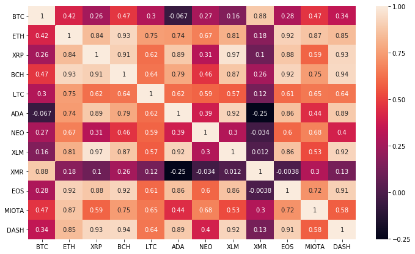

```python
plt.figure(figsize=(12,7))
sns.heatmap(crypto.corr(),annot=True)
```

```python
sns.pairplot(crypto)
```

[output not shown]

The next dataframe we are going to make is that of the returns from each crypto-currencies. It is nothing but the relative daily change in price.

The formula for returns for any crypto-currency is the same as that of stocks:

**percentage change in price = (current price - last price) / last price**

## Crypto-Currency Returns

```python
crypto_returns = crypto.pct_change()
```

```python
crypto_returns = crypto_returns.iloc[1:,:]
crypto_returns.head()
```

|  | BTC | ETH | XRP | BCH | LTC | ADA | NEO | XLM | XMR | EOS | MIOTA | DASH |
| --- | --- | --- | --- | --- | --- | --- | --- | --- | --- | --- | --- | --- |
| 2018-03-05 18:29:01 | 0.001224 | -0.000535 | -0.005159 | -0.000063 | -0.001417 | 0.002644 | 0.001733 | 0.009412 | -0.001832 | -0.000915 | -0.003030 | -0.000809 |
| 2018-03-05 18:09:01 | 0.001257 | 0.001451 | 0.005757 | 0.000487 | 0.000747 | 0.000876 | -0.010345 | 0.006376 | -0.008528 | 0.003131 | -0.000230 | 0.002780 |
| 2018-03-05 17:54:01 | -0.000791 | 0.001606 | 0.003175 | 0.000691 | -0.000033 | 0.006554 | -0.001026 | 0.002083 | -0.002706 | 0.003580 | 0.002282 | -0.002461 |
| 2018-03-05 17:44:02 | 0.002591 | 0.000273 | -0.007313 | 0.002433 | -0.000846 | 0.004754 | 0.000357 | 0.004991 | 0.000038 | 0.001057 | -0.002266 | 0.001638 |
| 2018-03-05 17:24:01 | -0.001666 | 0.000013 | 0.011772 | 0.000078 | 0.001504 | 0.006339 | 0.006988 | 0.006756 | -0.001805 | -0.000145 | -0.002105 | -0.000296 |

```python
crypto_returns.iplot(kind='scatter')
```

[interactive chart not shown]

The above plot shows that LITCOIN suffered a negative return(loss) for the month of february.

February 20th records the maximum returns for the month of february. This is shown below repectively.

```python
crypto_returns[crypto_returns['LTC'] == min(crypto_returns['LTC'])]
```

|  | BTC | ETH | XRP | BCH | LTC | ADA | NEO | XLM | XMR | EOS | MIOTA | DASH |
| --- | --- | --- | --- | --- | --- | --- | --- | --- | --- | --- | --- | --- |
| 2018-02-19 21:09:02 | -0.000026 | 0.008538 | 0.004953 | 0.011279 | -0.090856 | -0.005491 | 0.02035 | 0.030306 | 0.013523 | 0.013188 | 0.022026 | 0.009439 |

*LTC reached it's lowest returns at -0.090856 on Feb 19th.*

```python
crypto_returns[crypto_returns['LTC'] == max(crypto_returns['LTC'])]
```

|  | BTC | ETH | XRP | BCH | LTC | ADA | NEO | XLM | XMR | EOS | MIOTA | DASH |
| --- | --- | --- | --- | --- | --- | --- | --- | --- | --- | --- | --- | --- |
| 2018-02-20 12:54:02 | 0.041573 | 0.041025 | 0.047233 | 0.072943 | 0.050634 | 0.045632 | 0.054001 | 0.042389 | 0.071923 | 0.053516 | 0.068773 | 0.03731 |

*Feb 20 records a maximum peak for returns for the year of 2018 yet.*

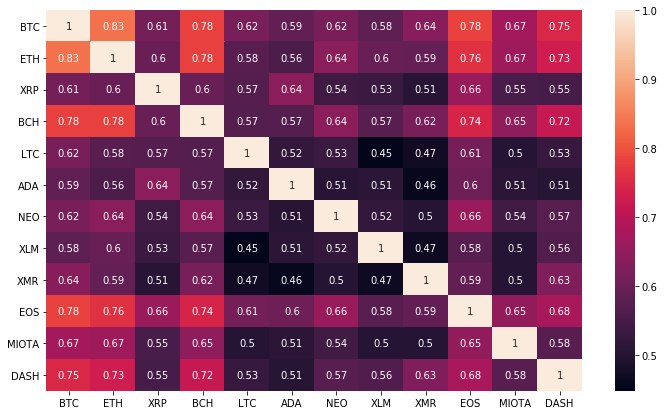

```python
plt.figure(figsize=(12,7))
sns.heatmap(crypto_returns.corr(),annot=True)
```

**There is relatively moderate correlation of crypto-currencies with each other when it comes to returns as shown by the correlation heatmap above.**

## Crypto-Currency in Bitcoins

```python
crypto_btc = pd.DataFrame()
for i in data[data['rank'] <= 10]['symbol'].unique():
    var = data[data['symbol']==i]['price_btc'].values
    ind = data[data['symbol']==i]['act_date'].values
    crypto_btc[i] = var
crypto_btc.set_index(ind,inplace=True)
```

```python
crypto_btc = crypto_btc.iloc[1:,:]
crypto_btc.head()
```

|  | BTC | ETH | XRP | BCH | LTC | ADA | NEO | XLM | XMR | EOS | MIOTA | DASH |
| --- | --- | --- | --- | --- | --- | --- | --- | --- | --- | --- | --- | --- |
| 2018-03-05 18:29:01 | 1.0 | 0.073893 | 0.000083 | 0.110094 | 0.018296 | 0.000026 | 0.009802 | 0.000031 | 0.032476 | 0.000697 | 0.000162 | 0.053120 |
| 2018-03-05 18:09:01 | 1.0 | 0.073809 | 0.000083 | 0.109864 | 0.018262 | 0.000026 | 0.009676 | 0.000031 | 0.032116 | 0.000697 | 0.000162 | 0.053131 |
| 2018-03-05 17:54:01 | 1.0 | 0.073940 | 0.000083 | 0.109958 | 0.018264 | 0.000026 | 0.009668 | 0.000031 | 0.032035 | 0.000700 | 0.000162 | 0.053009 |
| 2018-03-05 17:44:02 | 1.0 | 0.073828 | 0.000083 | 0.110028 | 0.018244 | 0.000026 | 0.009668 | 0.000031 | 0.032026 | 0.000701 | 0.000161 | 0.053080 |
| 2018-03-05 17:24:01 | 1.0 | 0.073915 | 0.000084 | 0.110166 | 0.018265 | 0.000026 | 0.009733 | 0.000031 | 0.031958 | 0.000700 | 0.000161 | 0.053047 |

```python
np.log(crypto_btc).iplot(kind='scatter')
```

[interactive chart not shown]

*The above plot shows that bitcoin is stable than trading crypto-currencies in dollars.The above graph concludes that making bitcoins as a indicator for index might be a good idea.*

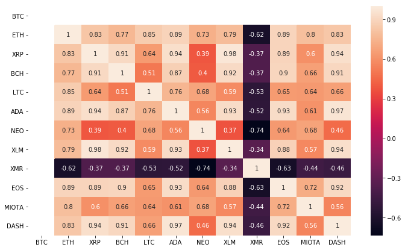

```python
plt.figure(figsize=(12,7))
sns.heatmap(crypto_btc.corr(),annot=True)
```

Again, The correlation heatmap shows a heavy correlation of crypto currency with each other. This can only mean that the prices of these currencies are directly influenced by the prices of bitcoin itself. Thus it can provide for a risk-return relationship which will be demonstrated in the Capital Asset Pricing Model Analysis.

# Data Analysis

In the following section, **Sharpe Ratio** will be used to exploit risky returns. Before moving to the next section it is important to point out about the term 'risk free rate'.

**Risk Free Rate** - The risk-free rate represents the interest an investor would expect from an absolutely risk-free investment over a specified period of time. In this case, the risk-free value is the price_btc of every crypto currency because it is least volatile.

**Sharpe Ratio** - The Sharpe ratio is the average return earned in excess of the risk-free rate per unit of volatility or total risk. Which is the difference of Crypto prices in dollars and crypto prices in Bitcoins and divided by the volatility of each crypto-currency. The greater the value of the Sharpe ratio, the more attractive the risk-adjusted return.

*Source - **Investopedia***

## Sharpe-Ratio

```python
sharpe = crypto - crypto_btc
```

```python
sharpe = sharpe.mean()/sharpe.std()
```

```python
sharpe
```

```
BTC      18.559995
ETH      22.986306
XRP      11.445741
BCH      11.363950
LTC      22.585005
ADA       9.336320
NEO      15.503939
XLM       8.622122
XMR      10.705616
EOS      13.604370
MIOTA    14.657341
DASH     13.890765
dtype: float64
```

```python
sharpe.iplot(kind='scatter',mode='markers',title='Sharpe Ratio')
```

[interactive chart not shown]

```python
print('GOOD INVESTMENT WOULD BE: ')
print(sharpe[sharpe > 14].sort_values(ascending=False))
```

```
GOOD INVESTMENT WOULD BE:
ETH      22.986306
LTC      22.585005
BTC      18.559995
NEO      15.503939
MIOTA    14.657341
dtype: float64
```

**Sortino Ratio** - What is the 'Sortino Ratio' The Sortino ratio is a variation of the Sharpe ratio that differentiates harmful volatility from total overall volatility by using the asset's standard deviation of negative asset returns, called downside deviation. The Sortino ratio takes the asset's return and subtracts the risk-free rate, and then divides that amount by the asset's downside deviation.

## SORTINO RATIO

```python
semi_var = (crypto_returns[crypto_returns < 0]) ** 2
```

```python
semi_var = np.sqrt(semi_var)
```

```python
sortino = semi_var.std()
```

```python
sortino_ratio = (crypto_returns - crypto_btc)
```

```python
sortino_ratio = sortino_ratio.mean()/sortino
```

```python
sortino_ratio.iplot(kind='scatter',mode='markers',title='Sortino Ratio')
```

[interactive chart not shown]

```python
sortino_ratio[sortino_ratio > -10]
```

```
XRP      0.019240
LTC     -3.824879
ADA      0.059386
NEO     -2.783942
XLM      0.040841
XMR     -6.743044
EOS     -0.193975
MIOTA   -0.013876
dtype: float64
```

Theoretically, the returns should be normally distributed. As shown in the section below:

## Histogram Of Returns

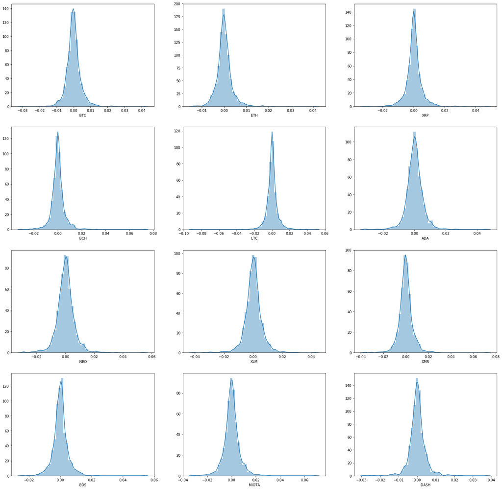

```python
plt.figure(figsize = (25,25))
for i in range(len(crypto_returns.columns)):
    plt.subplot(4,3,i+1)
    sns.distplot(crypto_returns.iloc[:,i].dropna())
    plt.xlabel(crypto_returns.columns[i])
```

```python
mean = list(np.mean(crypto_returns))
median = []
for i in crypto_returns.columns:
    median.append(np.median(crypto_returns[i]))
pd.DataFrame([mean,median],columns=crypto_returns.columns,index=['Mean','Median']).T
```

|  | Mean | Median |
| --- | --- | --- |
| BTC | -0.000040 | -0.000147 |
| ETH | 0.000093 | -0.000006 |
| XRP | 0.000162 | 0.000078 |
| BCH | 0.000144 | 0.000031 |
| LTC | 0.000069 | 0.000071 |
| ADA | 0.000247 | 0.000145 |
| NEO | 0.000135 | 0.000126 |
| XLM | 0.000218 | 0.000221 |
| XMR | -0.000085 | -0.000150 |
| EOS | 0.000164 | 0.000119 |
| MIOTA | 0.000117 | 0.000000 |
| DASH | 0.000123 | 0.000000 |

From the above analysis, it can be seen that the returns are nearly normally distributed. Although the mean and median of the returns do not match and thus leads to the suspicion that they have either longer tails and thus in the section below will determine the shape of the returns using skewness and kurtosis analysis.

# Skewness and Kurtosis

```python
from scipy.stats import skew
from scipy.stats import kurtosis
```

```python
skews =[]
kurts =[]
for s in crypto_returns.columns:
    skews.append(skew(crypto_returns[s].dropna()))
    kurts.append(kurtosis(crypto_returns[s].dropna()))
stats_sk = pd.DataFrame(skews,columns=['Skew'],index=crypto_returns.columns)
stats_sk['Kurtosis'] = kurts
```

```python
stats_sk['Kurtosis'].T.iplot(kind='scatter',mode='markers',title='Kurtosis')
```

[interactive chart not shown]

```python
stats_sk['Skew'].T.iplot(kind='scatter',mode='markers',title='Skewness')
```

[interactive chart not shown]

```python
print('Skewness and Kurtosis Summary: ')
print(stats_sk)
```

```
Skewness and Kurtosis Summary:
           Skew   Kurtosis
BTC    0.830471  11.209044
ETH    1.776815  17.499710
XRP    0.591059  10.945554
BCH    1.713576  23.307941
LTC   -1.440947  33.272169
ADA    0.259275   7.795930
NEO    0.495561   7.156517
XLM   -0.193942   6.811038
XMR    0.825923  14.956502
EOS    0.885351  12.245077
MIOTA  0.845909  10.793175
DASH   0.478780   9.405902
```

All the currencies whose skewness is positive indicates that they have a probability for lesser Negative outcomes. While LTC and XLM seems to have a probability for more negative outcomes.

Nearly all currencies have a kurtosis value greater than 3 which means that all the currencies have a probability for expected outcomes to have a value on the extremes of the returns.

# Capital Asset Pricing Model

What is the 'Capital Asset Pricing Model - CAPM' The capital asset pricing model (CAPM) is a model that describes the relationship between systematic risk and expected return for assets, particularly stocks. CAPM is widely used throughout finance for the pricing of risky securities, generating expected returns for assets given the risk of those assets and calculating costs of capital.

The Capital Asset Pricing Model says that the expected return of a security or a portfolio equals the rate on a risk-free security plus a risk premium. If this expected return does not meet or beat the required return, then the investment should not be undertaken. The security market line plots the results of the CAPM for all different risks (betas).The SML plots the asset's expected returns against its beta. For a security with a beta value of 1, its returns perfectly match the market's returns. Any security priced above the SML is deemed to be undervalued since investors expect a higher return given the same amount of risk. Conversely, any security priced below the SML is deemed to be overvalued.

**Source** - *Investopedia*

### Beta Values Calculation

```python
market_returns = crypto_btc.pct_change()
```

```python
crypto_returns = crypto_returns.iloc[1:,:]
```

```python
market_returns.dropna(inplace=True)
```

```python
print(len(market_returns),len(crypto_returns))
```

```
1482 1482
```

```python
beta = []
for i in crypto_returns.columns:
    ret_y = crypto_returns[i].reset_index(drop=True)
    ret_x = market_returns[i].reset_index(drop=True)

    ret_y = ret_y.values.reshape(-1,1)
    ret_x = ret_x.values.reshape(-1,1)
    from sklearn.linear_model import LinearRegression
    model = LinearRegression()
    results = model.fit(ret_x,ret_y)
    beta.append(results.coef_[0])
```

```python
mean_rets = []
for i in crypto_returns.columns:
    mean_rets.append(np.mean(crypto_btc[i]))
```

```python
capm = pd.DataFrame(beta,columns=['beta'])
```

```python
capm['Mean Returns'] = mean_rets
```

```python
capm['CATS'] = crypto_returns.columns
```

[output not shown]

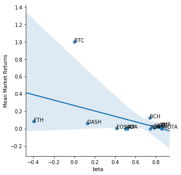

```python
plt.figure(figsize=(12,7))
sns.lmplot('beta','Mean Returns',capm)
for i, txt in enumerate(capm['CATS']):
    plt.annotate(txt, (capm['beta'][i],capm['Mean Returns'][i]))
plt.ylabel('Mean Market Returns')

print(capm[['CATS','beta']])
```